# Week 09: R for Data Analytics - Regression Analysis

## Part 6: Detecting Outliers & Influential Cases

### Outliers

Outliers are extreme observations that deviate from the pattern:

> **Plain English:** An **outlier** is a case that differs substantially from the main trend of the data. Imagine a regression predicting weight from height; a person who is very short but extremely heavy would be an outlier. These “weird” cases can bias the model, pulling the regression line towards them and making it less accurate for everyone else.

```r
# Standardized residuals (residuals divided by SD)
std_residuals <- rstandard(model_multiple)

# Cases with |std residual| > 2.5 are potentially problematic
outlier_cases <- which(abs(std_residuals) > 2.5)
cat("Potential outliers (std residuals > 2.5):\n")
```

```
## Potential outliers (std residuals > 2.5):
```

```r
print(outlier_cases)
```

```
##   1  34  49  66 164 167 195 197 244
##   1  34  49  66 164 167 195 197 244
```

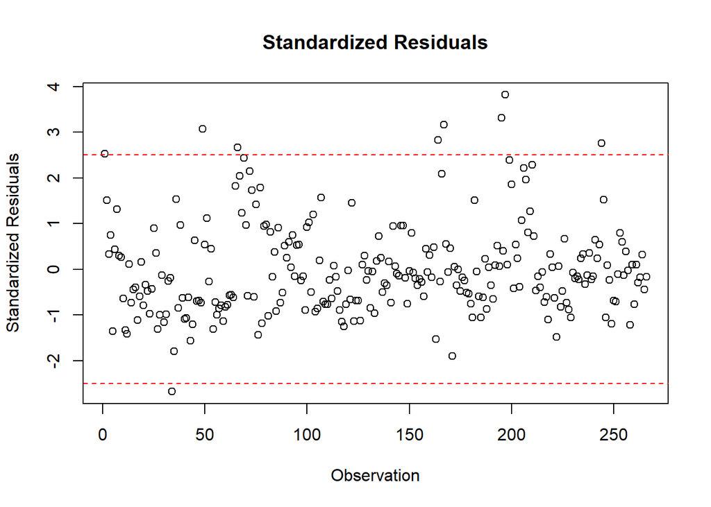

```r
# Plot standardized residuals
plot(std_residuals,
     main = "Standardized Residuals",
     ylab = "Standardized Residuals",
     xlab = "Observation")
abline(h = c(-2.5, 2.5), col = "red", lty = 2)
```

### Leverage

Leverage measures how extreme a case is on the predictor variables:

```r
# Leverage (hat values)
leverage <- hatvalues(model_multiple)

# Average leverage = (p+1)/n where p = number of predictors
p <- 3  # number of predictors
n <- nrow(regression_data_clean)
avg_leverage <- (p + 1) / n

cat("Average leverage:", avg_leverage, "\n")
```

```
## Average leverage: 0.01503759
```

```r
cat("Cases with high leverage (>", 2*avg_leverage, "):\n")
```

```
## Cases with high leverage (> 0.03007519 ):
```

```r
high_leverage <- which(leverage > 2*avg_leverage)
print(high_leverage)
```

```
##   2  34  39  46  50  63  65  68  70  78  84  89 176 201 203 215 231 244 245
##   2  34  39  46  50  63  65  68  70  78  84  89 176 201 203 215 231 244 245
```

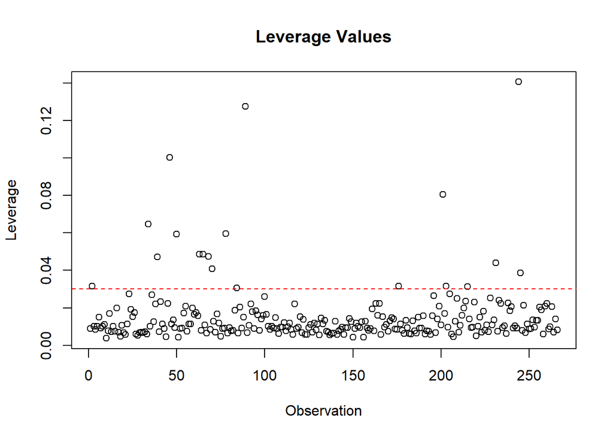

```r
# Plot leverage
plot(leverage, main = "Leverage Values", ylab = "Leverage", xlab = "Observation")
abline(h = 2*avg_leverage, col = "red", lty = 2)
```

### Cook’s Distance

Cook’s Distance measures influential cases (high leverage AND high residuals):

```r
# Cook's D
cooks_d <- cooks.distance(model_multiple)

# Threshold is often 4/(n-p-1)
threshold <- 4 / (n - p - 1)

cat("Threshold for Cook's D:", threshold, "\n")
```

```
## Threshold for Cook's D: 0.01526718
```

```r
cat("Influential cases:\n")
```

```
## Influential cases:
```

```r
influential <- which(cooks_d > threshold)
print(influential)
```

```
##   2  34  36  49  65  66  68  78 164 167 195 197 199 244 245
##   2  34  36  49  65  66  68  78 164 167 195 197 199 244 245
```

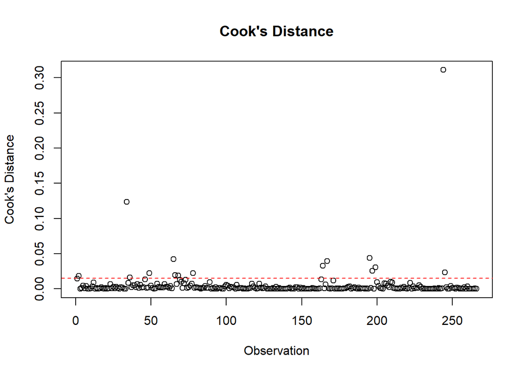

```r
# Plot Cook's D
plot(cooks_d, main = "Cook's Distance", ylab = "Cook's Distance", xlab = "Observation")
abline(h = threshold, col = "red", lty = 2)
```

### All Diagnostics Together

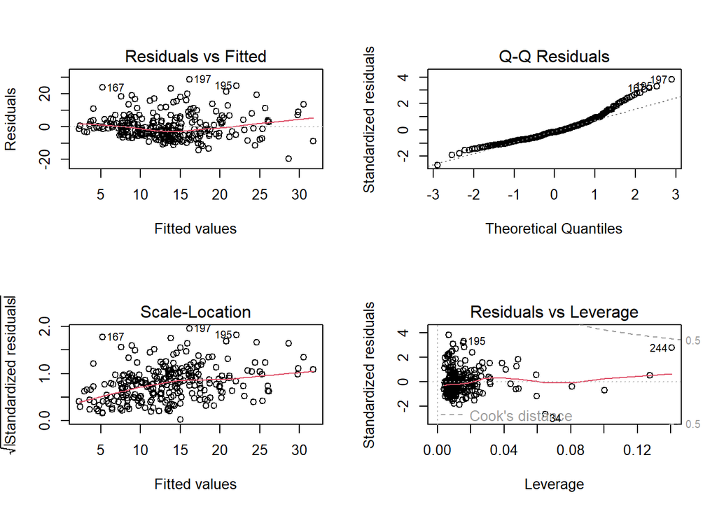

```r
# Comprehensive diagnostic plots
par(mfrow = c(2, 2))
plot(model_multiple)
```

```r
par(mfrow = c(1, 1))
```

## Part 7: Multicollinearity

When predictors are highly correlated with each other, it creates multicollinearity, which inflates standard errors and reduces precision:

> **Plain English (Multicollinearity):** Multicollinearity means that the predictor variables are too closely related to each other. Crudely put, it means the b-values (coefficients) are less trustworthy. As Andy Field says: “Don’t lend them money and don’t let them go for dinner with your boy- or girlfriend.” If variables are too similar, the model can’t tell which one is actually doing the predicting.

```r
# Variance Inflation Factor (VIF)
# VIF > 10 indicates problematic multicollinearity
# VIF > 5 is concerning
vif(model_multiple)
```

```
##       PIL_total AUDIT_TOTAL_NEW  DAST_TOTAL_NEW
##        1.031853        1.373162        1.388818
```

```r
# Correlation matrix of predictors
predictor_corr <- regression_data_clean %>%
  dplyr::select(PIL_total, AUDIT_TOTAL_NEW, DAST_TOTAL_NEW) %>%
  cor()

print(predictor_corr)
```

```
##                  PIL_total AUDIT_TOTAL_NEW DAST_TOTAL_NEW
## PIL_total        1.0000000      -0.1310385     -0.1680770
## AUDIT_TOTAL_NEW -0.1310385       1.0000000      0.5194087
## DAST_TOTAL_NEW  -0.1680770       0.5194087      1.0000000
```

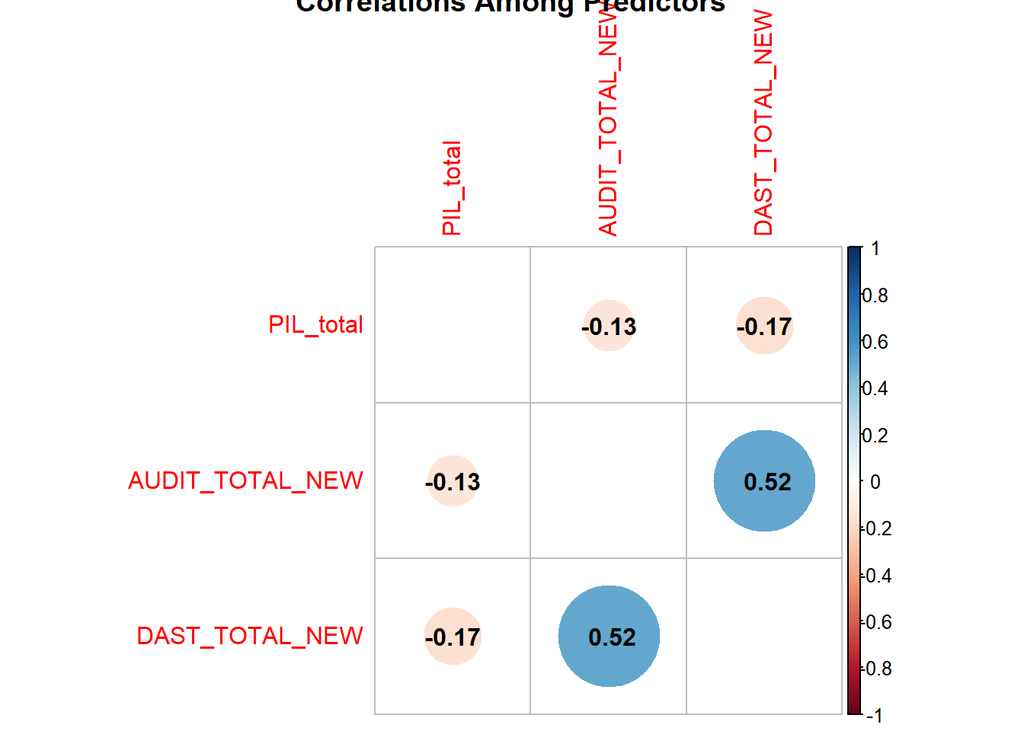

```r
# Visualize correlations
corrplot(predictor_corr, method = "circle",
         addCoef.col = "black", diag = FALSE,
         title = "Correlations Among Predictors")
```

## Part 8: Hierarchical Regression

Hierarchical regression allows us to test whether adding predictors significantly improves model fit:

```r
# Model 1: PIL only
model_h1 <- lm(CESD_total ~ PIL_total, data = regression_data_clean)

# Model 2: Add substance use
model_h2 <- lm(CESD_total ~ PIL_total + AUDIT_TOTAL_NEW + DAST_TOTAL_NEW,
               data = regression_data_clean)

# Compare models
cat("Model 1 R²:", summary(model_h1)$r.squared, "\n")
```

```
## Model 1 R²: 0.3418214
```

```r
cat("Model 2 R²:", summary(model_h2)$r.squared, "\n")
```

```
## Model 2 R²: 0.3586693
```

```r
# F-test for improvement
anova(model_h1, model_h2)
```

|  | Res.Df | RSS | Df | Sum of Sq | F | Pr(>F) |
| --- | --- | --- | --- | --- | --- | --- |
| 1 | 264 | 15470.48 | NA | NA | NA | NA |
| 2 | 262 | 15074.47 | 2 | 396.0093 | 3.441395 | 0.03347459 |

```r
# The p-value tells us if Model 2 is significantly better than Model 1
```

## Part 9: Effect Sizes in Regression

### R-squared

R² tells us the proportion of variance in Y explained by the model:

```r
r2 <- summary(model_multiple)$r.squared
cat("R-squared:", r2, "\n")
```

```
## R-squared: 0.3586693
```

```r
cat("This means", r2*100, "% of variance in depression is explained by the model\n")
```

```
## This means 35.86693 % of variance in depression is explained by the model
```

```r
# Adjusted R² penalizes for number of predictors
adj_r2 <- summary(model_multiple)$adj.r.squared
cat("Adjusted R-squared:", adj_r2, "\n")
```

```
## Adjusted R-squared: 0.3513258
```

### Semi-partial (Part) Correlations

These correlations show the unique contribution of each predictor, removing the shared variance with other predictors:

```r
# Semi-partial correlations
spcor_results <- spcor.test(regression_data_clean$CESD_total,
                            regression_data_clean$PIL_total,
                            as.matrix(regression_data_clean[, c("AUDIT_TOTAL_NEW", "DAST_TOTAL_NEW")]))
cat("Semi-partial correlation for PIL_total:", spcor_results$estimate, "\n")
```

```
## Semi-partial correlation for PIL_total: -0.5578727
```

```r
cat("p-value:", spcor_results$p.value, "\n")
```

```
## p-value: 5.378433e-23
```

```r
# Semi-partial correlation squared = unique variance explained
cat("Unique variance explained by PIL_total:", spcor_results$estimate^2 * 100, "%\n")
```

```
## Unique variance explained by PIL_total: 31.1222 %
```

## Part 10: APA-Formatted Output

### Regression Table

```r
# Extract model summary
model_summary <- summary(model_multiple)

# Create APA table
regression_table <- data.frame(
  Predictor = c("Intercept", "PIL_total", "AUDIT_TOTAL_NEW", "DAST_TOTAL_NEW"),
  b = coef(model_multiple),
  SE = model_summary$coefficients[, 2],
  t = model_summary$coefficients[, 3],
  p = model_summary$coefficients[, 4]
)

# Format for APA
kable(regression_table,
      digits = 3,
      caption = "Table 1. Multiple Regression Predicting Depression from Purpose in Life, Alcohol Use, and Drug Use",
      format = "html") %>%
  kable_styling("striped")
```

Table 1. Multiple Regression Predicting Depression from Purpose in Life, Alcohol Use, and Drug Use

|  | Predictor | b | SE | t | p |
| --- | --- | --- | --- | --- | --- |
| (Intercept) | Intercept | 55.164 | 3.889 | 14.184 | 0.000 |
| PIL_total | PIL_total | -0.382 | 0.034 | -11.276 | 0.000 |
| AUDIT_TOTAL_NEW | AUDIT_TOTAL_NEW | -0.092 | 0.094 | -0.981 | 0.328 |
| DAST_TOTAL_NEW | DAST_TOTAL_NEW | 1.034 | 0.399 | 2.594 | 0.010 |

```r
cat("\nNote. R² =", round(model_summary$r.squared, 3),
    ", adjusted R² =", round(model_summary$adj.r.squared, 3), "\n")
```

```
##
## Note. R² = 0.359 , adjusted R² = 0.351
```

### Model Summary Table

```r
# Compare models
models_comparison <- data.frame(
  Model = c("1. PIL only", "2. PIL + Substance Use"),
  R2 = c(summary(model_h1)$r.squared, summary(model_h2)$r.squared),
  Adj_R2 = c(summary(model_h1)$adj.r.squared, summary(model_h2)$adj.r.squared),
  F = c(summary(model_h1)$fstatistic[1], summary(model_h2)$fstatistic[1])
)

kable(models_comparison,
      digits = 3,
      caption = "Table 2. Comparison of Regression Models") %>%
  kable_styling("striped")
```

Table 2. Comparison of Regression Models

Model

R2

Adj_R2

F

1. PIL only

0.342

0.339

137.107

2. PIL + Substance Use

0.359

0.351

48.842

## Part 11: When Assumptions Are Violated

### What If Data Are Non-Normal?

If residuals are non-normally distributed: - Consider data transformations (log, square root) - Use robust regression methods - Report bootstrapped confidence intervals

### What If We Have Heteroscedasticity?

If variance of residuals is unequal: - Use weighted least squares regression - Report heteroscedasticity-consistent standard errors - Consider transforming the outcome variable

### What If We Have Outliers/Influential Cases?

- Examine why the case is unusual
- Check for data entry errors
- Consider robust regression that downweights influential cases
- Report results with and without outliers for comparison

## Summary & Key Points

✓ **Regression extends correlation** by allowing prediction and testing directional relationships

✓ **Simple regression** involves one predictor; **multiple regression** involves several

✓ **Interpretation depends on scaling:** Unstandardized coefficients (b) vs. standardized (β)

✓ **R² measures model fit:** The proportion of outcome variance explained

✓ **Always check assumptions:** Linearity, normality, homoscedasticity, independence

✓ **Diagnose problems:** Use plots, tests (Shapiro-Wilk, VIF), and distance measures (Cook’s D, leverage)

✓ **Hierarchical regression** tests whether added predictors improve model fit

✓ **Effect sizes** (R², semi-partial correlations) quantify the practical importance of relationships

## References

[1] Field, A., Miles, J., & Field, Z. (2012). *Discovering statistics using R*. Sage Publications.

## Further Resources

- **Textbook:** Chapter 7 in Field, Miles, & Field (2012)
- **Visualization:** Use `plot(model)` for quick diagnostic checks
- **Robust methods:** See `rlm()` in the `MASS` package for robust regression
- **Cross-validation:** Use `caret` package for evaluating model generalization

*Tutorial created for ANLY500: Analytics I* *Enter Your Name | Date: 2026-01-29*